# Normalisation

Normalisation is the operation of bringing indicators onto comparable scales so that they can be aggregated more fairly. To see why this is necessary, consider aggregating GDP values (billions or trillions of dollars) with percentage tertiary graduates (tens of percent). Average values here would make no sense because one is on a completely different scale to the other.

The normalisation function in COINr is imaginatively named `Normalise()`. It has the following main features:

- A wide range of normalisation methods, including the possibility to pass custom functions
- Customisable parameters for normalisation
- Possibility to specify detailed individual treatment for each indicator

As of COINr v1.0, `Normalise()` is a generic function with methods for different classes. This means that `Normalise()` can be called on coins, but also on data frames, numeric vectors and purses (time-indexed collections of coins).

Since `Normalise()` might be a bit over-complicated for some applications, the `qNormalise()` function gives a simpler interface which might be easier to use. See the Simplified normalisation section.

# Coins

The `Normalise()` method for coins follows the familiar format: you have to specify:

- `x` the coin
- `global_specs` default specifications to apply to all indicators
- `indiv_specs` individual specifications to override `global_specs` for specific indicators, if required
- `directions` a data frame specifying directions - this overrides the directions in `iMeta` if specified
- `out2` whether to output an updated coin or simply a data frame

Let’s begin with a simple example. We build the example coin and normalise the raw data.

```r
library(COINr)

# build example coin
coin <- build_example_coin(up_to = "new_coin")
```

```
#> iData checked and OK.
#> iMeta checked and OK.
#> Written data set to .$Data$Raw
```

```r
# normalise the raw data set
coin <- Normalise(coin, dset = "Raw")
```

```
#> Written data set to .$Data$Normalised
```

We can compare one of the raw and un-normalised indicators side by side.

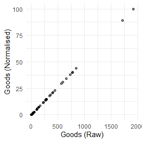

```r
plot_scatter(coin, dsets = c("Raw", "Normalised"), iCodes = "Goods")
```

This plot also illustrates the linear nature of the min-max transformation.

The default normalisation uses the min-max approach, scaling indicators onto the $[0, 100]$ interval. But we can change the normalisation type and its parameters using the `global_specs` argument.

```r
coin <- Normalise(coin, dset = "Raw",
                   global_specs = list(f_n = "n_zscore",
                                        f_n_para = list(c(10,2))))
```

```
#> Written data set to .$Data$Normalised
#> (overwritten existing data set)
```

Again, let’s plot an example of the result:

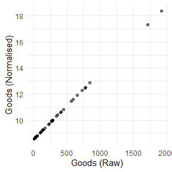

```r
plot_scatter(coin, dsets = c("Raw", "Normalised"), iCodes = "Goods")
```

Again, the z-score transformation is linear. It simply puts the resulting indicator on a different scale.

Notice the syntax of `global_specs`. If specified, it takes entries `f_n` (the name of the function to apply to each column) and `f_n_para` (any further arguments to `f_n`, not including `x`). Importantly, `f_n_para` *must* be specified as a list, even if it only contains one parameter.

Note that **COINr has a number of normalisation functions built in**, all of which are of the form `n_*()`, such as `n_minmax()`, `n_borda()`, etc. Type `n_` in the R Studio console and press the Tab key to see a list, or else browse the COINr functions alphabetically. These are also listed explicitly in Built-in normalisation functions.

## Calling external functions

Since `f_n` points to a function name, any function can be passed to `Normalise()` as long as it is available in the namespace. To illustrate, consider an example where we want to categorise into discrete bins. We can use base R’s `cut()` function for this purpose. We simply need to specify the number of bins. We could directly call `cut()`, but for clarity we will create a simple wrapper function around it, then pass that function to `Normalise()`.

```r
# wrapper function
f_bin <- function(x, nbins){
  cut(x, breaks = nbins, labels = FALSE)
}

# pass wrapper to normalise, specify 5 bins
coin <- Normalise(coin, dset = "Raw",
                   global_specs = list(f_n = "f_bin",
                                        f_n_para = list(nbins = 5)))
```

```
#> Written data set to .$Data$Normalised
#> (overwritten existing data set)
```

To illustrate the difference with the linear transformations above, we again plot the raw against normalised indicator:

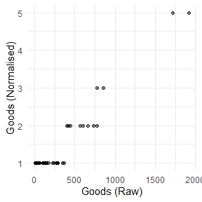

```r
plot_scatter(coin, dsets = c("Raw", "Normalised"), iCodes = "Goods")
```

Obviously this is *not* linear.

Generally, the requirements of a function to be passed to `Normalise()` are that its first argument should be `x`, a numeric vector, and it should return a numeric vector of the same length as `x`. It should also be able to handle `NA`s. Any further arguments can be passed via the `f_n_para` entry.

## Directions

By default, the directions are taken from the coin. These will have been specified as the `Direction` column of `iMeta` when constructing a coin with `new_coin()`. However, you can specify different directions using the `directions` argument of `normalise()`: in this case you need to specify a data frame with two columns: `iCode` (with an entry for each indicator code found in the target data set) and `Direction` giving the direction as -1 or 1.

To show an example, we take the existing directions from the coin, modify them slightly, and then run the normalisation function again:

```r
# get directions from coin
directions <- coin$Meta$Ind[c("iCode", "Direction")]

head(directions, 10)
```

```
#>       iCode Direction
#> 9     Goods         1
#> 10 Services         1
#> 11      FDI         1
#> 12   PRemit         1
#> 13  ForPort         1
#> 31    Renew         1
#> 32 PrimEner        -1
#> 33      CO2        -1
#> 34   MatCon        -1
#> 35   Forest        -1
```

We’ll change the direction of the “Goods” indicator and re-normalise:

```r
# change Goods to -1
directions$Direction[directions$iCode == "Goods"] <- -1

# re-run (using min max default)
coin <- Normalise(coin, dset = "Raw", directions = directions)
```

```
#> Written data set to .$Data$Normalised
#> (overwritten existing data set)
```

## Goalposts, targets and iMeta specification

For some normalisation methods we may use the same basic normalisation function for all indicators but use different parameters for each indicator - for example, using distance to target normalisation or goalpost normalisation. COINr now supports specifying these parameters in the `iMeta` table. This is intended to give an easier interface to these normalisation methods, as opposed to using the full individual specifications list (see the next section on that).

The basic idea is that you specify the parameters as columns in the `iMeta` data frame. COINr currently supports this for a selected subset of inbuilt normalisation functions:

- `n_minmax()`
- `n_scaled()`
- `n_zscore()`
- `n_dist2targ()`
- `n_goalposts()`

To use this approach, you have to (a) add the relevant columns to `iMeta` *before* building the coin, and (b) set `f_n_para = "use_iMeta"` within the `global_specs` list when calling `Normalise()`.

Let’s clarify this with an example. We will apply distance to target normalisation using individual targets contained within `iMeta`. In fact, the example data with COINr already has a “Target” column which can be used for this purpose:

```r
# show first few rows of iCode and Target cols in built-in iMeta
head(ASEM_iMeta[c("iCode", "Target")])
```

```
#>     iCode     Target
#> 1     LPI   4.118031
#> 2 Flights 200.332655
#> 3    Ship  20.113377
#> 4    Bord 115.900000
#> 5    Elec 104.670585
#> 6     Gas  90.060420
```

The [documentation](https://bluefoxr.github.io/COINr/reference/n_dist2targ.html?q=n_dist#null) for the `n_dist2targ()` function explains that the required `iMeta` columns for this function are `Target`, and `dist2targ_cap_max`. This latter parameter (which specifies whether to cap values that surpass the target) is included for completeness, even though it is unlikely you would want to vary it from one indicator to another. Since the Target column is already present, we will just add the missing column:

```r
# copy built in data
iMeta <- ASEM_iMeta
# set cap_max
iMeta$dist2targ_cap_max <- TRUE
```

Now we build the coin and normalise.

```r
# build coin
coin <- new_coin(ASEM_iData, iMeta, quietly = TRUE)

# normalise, referencing iMeta columns
coin <- Normalise(coin, dset = "Raw", global_specs = list(f_n = "n_dist2targ", f_n_para = "use_iMeta"))
```

```
#> Written data set to .$Data$Normalised
```

Note that the `global_specs$f_n_para` is set to `"use_iMeta"`, telling the function to use the `iMeta` columns. Let us visualise the result for a selected indicator:

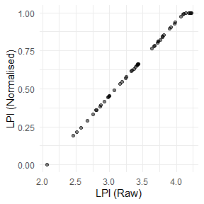

```r
plot_scatter(coin, dsets = c("Raw", "Normalised"), iCodes = "LPI")
```

This simply shows that (a) the indicator is now scaled between 0 and 1, and any raw values of LPI above the target of 4.1 are capped at a value of 1.

We now take another example using the “goalposts” approach, also known as “distance to frontier”. In this method, each indicator is scaled as a distance between an upper and lower bound. The following equation is for a positive direction indicator.

$$x_n = \frac{x - G_{low}}{G_{high} -
G_{low}}$$

where $x_n$ is the normalised indicator value and $G_{low}$ and $G_{high}$ are respectively the lower and upper goalpost values. The negative direction formula is analogous.

To use this approach we again need to define the necessary columns in `iMeta`. Referencing again the documentation of the relevant function `n_goalposts()`, we need to add columns `goalpost_lower`, `goalpost_upper`, `goalpost_scale` and `goalpost_trunc2posts`, which correspond to arguments to the `n_goalposts()` function.

For the sake of this example, we just define goalposts as 5% of the range from the maximum and minimum of each indicator. We set the scaling to 1 and truncation to `TRUE`.

```r
# get iCodes and raw data
iCodes <- iMeta$iCode[iMeta$Type == "Indicator"]

# set general parameters
iMeta$goalpost_scale <- 1
iMeta$goalpost_trunc2posts <- TRUE

# set goalposts for each indicator
for(iCode in iCodes){
  maxx <- max(ASEM_iData[[iCode]], na.rm = TRUE)
  minx <- min(ASEM_iData[[iCode]], na.rm = TRUE)
  rx <- maxx - minx
  # fake goalposts in 5% of range
  iMeta$goalpost_lower[iMeta$iCode == iCode] <- minx + 0.05*rx
  iMeta$goalpost_upper[iMeta$iCode == iCode] <- maxx - 0.05*rx
}

# build coin
coin <- new_coin(ASEM_iData, iMeta, quietly = TRUE)

# normalise using minmax
coin <- Normalise(coin, dset = "Raw",
                  global_specs = list(f_n = "n_goalposts", f_n_para = "use_iMeta"))
```

```
#> Written data set to .$Data$Normalised
```

Again, let’s plot an indicator before and after normalisation:

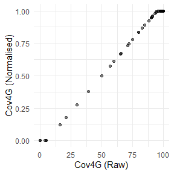

```r
plot_scatter(coin, dsets = c("Raw", "Normalised"), iCodes = "Cov4G")
```

Here we see that goalposts act like distance to target, but also cap at both ends.

Importantly, all of the functions mentioned in this section can also be used without the special columns in `iMeta`, either by specifying a single set of parameters to apply to all indicators using `global_specs`, OR by providing detailed individual specifications via the `indiv_specs` argument (see the next section).

## Individual normalisation

Finally let’s explore how to specify different normalisation methods for different indicators. The `indiv_specs` argument takes a named list for each indicator, and will override the specifications in `global_specs`. If `indiv_specs` is specified, we only need to include sub-lists for indicators that differ from `global_specs`.

```r
# individual specifications:
# LPI - borda scores
# Flights - z-scores with mean 10 and sd 2
indiv_specs <- list(
  LPI = list(f_n = "n_borda"),
  Flights = list(f_n = "n_zscore",
                 f_n_para = list(m_sd = c(10, 2)))
)

# normalise
coin <- Normalise(coin, dset = "Raw", indiv_specs = indiv_specs)
```

```
#> Written data set to .$Data$Normalised
#> (overwritten existing data set)
```

```r
# a quick look at the first three indicators
get_dset(coin, "Normalised")[1:4] |>
  head(10)
```

```
#>    uCode LPI   Flights      Ship
#> 1    AUS  36  9.889993  66.14497
#> 2    AUT  44  9.588735   0.00000
#> 3    BEL  45  9.711512  97.14314
#> 4    BGD   4  8.529810  45.80661
#> 5    BGR   7  8.741971  37.40495
#> 6    BRN   9  8.433044  35.38920
#> 7    CHE  42 10.563483   0.00000
#> 8    CHN  30 13.235114 100.00000
#> 9    CYP  14  8.721372  55.21211
#> 10   CZE  31  9.001961   0.00000
```

This example is meant to be illustrative of the functionality of `Normalise()`, rather than being a sensible normalisation strategy, because the indicators are now on very different ranges.

In practice, if different normalisation strategies are selected, it is a good idea to keep the indicators on similar ranges, otherwise the effects will be very unequal in the aggregation step.

# Data frames and vectors

Normalising a data frame is very similar to normalising a coin, except the input is a data frame and output is also a data frame.

```r
mtcars_n <- Normalise(mtcars, global_specs = list(f_n = "n_dist2max"))

head(mtcars_n)
```

```
#>         mpg cyl      disp        hp      drat        wt      qsec vs am gear
#> 1 0.4510638 0.5 0.2217511 0.2049470 0.5253456 0.2830478 0.2333333  0  1  0.5
#> 2 0.4510638 0.5 0.2217511 0.2049470 0.5253456 0.3482485 0.3000000  0  1  0.5
#> 3 0.5276596 0.0 0.0920429 0.1448763 0.5023041 0.2063411 0.4892857  1  1  0.5
#> 4 0.4680851 0.5 0.4662010 0.2049470 0.1474654 0.4351828 0.5880952  1  0  0.0
#> 5 0.3531915 1.0 0.7206286 0.4346290 0.1797235 0.4927129 0.3000000  0  0  0.0
#> 6 0.3276596 0.5 0.3838863 0.1872792 0.0000000 0.4978266 0.6809524  1  0  0.0
#>        carb
#> 1 0.4285714
#> 2 0.4285714
#> 3 0.0000000
#> 4 0.0000000
#> 5 0.1428571
#> 6 0.0000000
```

As with coins, columns can be normalised with individual specifications using the `indiv_spec` argument in exactly the same way as with a coin. Note that non-numeric columns are always ignored:

```r
Normalise(iris) |>
  head()
```

```
#>   Sepal.Length Sepal.Width Petal.Length Petal.Width Species
#> 1    22.222222    62.50000     6.779661    4.166667  setosa
#> 2    16.666667    41.66667     6.779661    4.166667  setosa
#> 3    11.111111    50.00000     5.084746    4.166667  setosa
#> 4     8.333333    45.83333     8.474576    4.166667  setosa
#> 5    19.444444    66.66667     6.779661    4.166667  setosa
#> 6    30.555556    79.16667    11.864407   12.500000  setosa
```

There is also a method for numeric vectors, although usually it is just as easy to call the underlying normalisation function directly.

```r
# example vector
x <- runif(10)

# normalise using distance to reference (5th data point)
x_norm <- Normalise(x, f_n = "n_dist2ref", f_n_para = list(iref = 5))

# view side by side
data.frame(x, x_norm)
```

```
#>             x    x_norm
#> 1  0.72649044 0.9070981
#> 2  0.69014298 0.8603513
#> 3  0.71527202 0.8926700
#> 4  0.02118719 0.0000000
#> 5  0.79872519 1.0000000
#> 6  0.71026957 0.8862363
#> 7  0.67692102 0.8433463
#> 8  0.60600435 0.7521397
#> 9  0.46573485 0.5717375
#> 10 0.75824102 0.9479329
```

# Purses

The purse method for `normalise()` is especially useful if you are working with multiple coins and panel data. This is because to make scores comparable from one time point to the next, it is usually a good idea to normalise indicators together rather than separately. For example, with the min-max method, indicators are typically normalised using the minimum and maximum over all time points of data, as opposed to having a separate max and min for each.

This means that the purse method for `normalise()` is a bit different from most other purse methods, because it doesn’t independently apply the function to each coin, but takes the coins all together. This has the following implications:

1. Any normalisation function can be applied globally to all coins in a purse, ensuring comparability. BUT:
2. If normalisation is done globally, it is no longer possible to automatically regenerate coins in the purse (i.e. using `regenerate()`), because the coin is no longer self-contained: it needs to know the values of the other coins in the purse. Perhaps at some point I will add a dedicated method for regenerating entire purses, but we are not there yet.

Let’s anyway illustrate with an example. We build the example purse first.

```r
purse <- build_example_purse(quietly = TRUE)
```

Normalising a purse works in exactly the same way as normalising a coin, except for the `global` argument. By default, `global = TRUE`, which means that the normalisation will be applied over all time points simultaneously, with the aim of making the index comparable. Here, we will apply the default min-max approach to all coins:

```r
purse <- Normalise(purse, dset = "Raw", global = TRUE)
```

```
#> Written data set to .$Data$Normalised
#> (overwritten existing data set)
#> Written data set to .$Data$Normalised
#> (overwritten existing data set)
#> Written data set to .$Data$Normalised
#> (overwritten existing data set)
#> Written data set to .$Data$Normalised
#> (overwritten existing data set)
#> Written data set to .$Data$Normalised
#> (overwritten existing data set)
```

Now let’s examine the data set of the first coin. We’ll see what the max and min of a few indicators is:

```r
# get normalised data of first coin in purse
x1 <- get_dset(purse$coin[[1]], dset = "Normalised")

# get min and max of first four indicators (exclude uCode col)
sapply(x1[2:5], min, na.rm = TRUE)
```

```
#>     LPI Flights    Ship    Bord
#>       0       0       0       0
```

```r
sapply(x1[2:5], max, na.rm = TRUE)
```

```
#>      LPI  Flights     Ship     Bord
#> 83.98913 88.79325 85.91861 93.62416
```

Here we see that the minimum values are zero, but the maximum values are *not* 100, because in other coins these indicators have higher values. To show that the global maximum is indeed 100, we can extract the whole normalised data set for all years and run the same check.

```r
# get entire normalised data set for all coins in one df
x1_global <- get_dset(purse, dset = "Normalised")

# get min and max of first four indicators (exclude Time and uCode cols)
sapply(x1_global[3:6], min, na.rm = TRUE)
```

```
#>     LPI Flights    Ship    Bord
#>       0       0       0       0
```

```r
sapply(x1_global[3:6], max, na.rm = TRUE)
```

```
#>     LPI Flights    Ship    Bord
#>     100     100     100     100
```

Any type of normalisation can be performed on a purse in this “global” mode. However, keep in mind what is going on. Simply put, when `global = TRUE` this is what happens:

1. The data sets from each coin are joined together into one using the `get_dset()` function.
2. Normalisation is applied to this global data set.
3. The global data set is then split back into the coins.

So if you specify to normalise by e.g. rank, ranks will be calculated for all time points. Therefore, consider carefully if this fits the intended meaning.

Normalisation can also be performed independently on each coin, by setting `global = FALSE`.

```r
purse <- Normalise(purse, dset = "Raw", global = FALSE)
```

```
#> Written data set to .$Data$Normalised
#> (overwritten existing data set)
#> Written data set to .$Data$Normalised
#> (overwritten existing data set)
#> Written data set to .$Data$Normalised
#> (overwritten existing data set)
#> Written data set to .$Data$Normalised
#> (overwritten existing data set)
#> Written data set to .$Data$Normalised
#> (overwritten existing data set)
```

```r
# get normalised data of first coin in purse
x1 <- get_dset(purse$coin[[1]], dset = "Normalised")

# get min and max of first four indicators (exclude uCode col)
sapply(x1[2:5], min, na.rm = TRUE)
```

```
#>     LPI Flights    Ship    Bord
#>       0       0       0       0
```

```r
sapply(x1[2:5], max, na.rm = TRUE)
```

```
#>     LPI Flights    Ship    Bord
#>     100     100     100     100
```

Now the normalised data set in each coin will have a min and max of 0 and 100 respectively, for each indicator.

# Simplified normalisation

If the syntax of `Normalise()` looks a bit over-complicated, you can use the simpler `qNormalise()` function, which has less flexibility but makes the key function arguments more visible (they are not wrapped in lists). This function applies the same normalisation method to all indicators. It is also a generic so can be used on data frames, coins and purses. Let’s demonstrate on a data frame:

```r
# some made up data
X <- data.frame(uCode = letters[1:10],
                a = runif(10),
                b = runif(10)*100)

X
```

```
#>    uCode         a         b
#> 1      a 0.3179556 25.341877
#> 2      b 0.1917927 54.717433
#> 3      c 0.5785375  1.261268
#> 4      d 0.6302498 30.292342
#> 5      e 0.3874103 64.065780
#> 6      f 0.8182025 61.125191
#> 7      g 0.6723450 52.538502
#> 8      h 0.9993705 74.775695
#> 9      i 0.3583237 13.959335
#> 10     j 0.7046756 85.904824
```

By default, normalisation results in min-max on the $[0, 100]$ interval:

```r
qNormalise(X)
```

```
#>    uCode         a         b
#> 1      a  15.62237  28.44943
#> 2      b   0.00000  63.15444
#> 3      c  47.88947   0.00000
#> 4      d  54.29286  34.29803
#> 5      e  24.22275  74.19881
#> 6      f  77.56650  70.72473
#> 7      g  59.50539  60.58020
#> 8      h 100.00000  86.85177
#> 9      i  20.62105  15.00181
#> 10     j  63.50879 100.00000
```

We can pass another normalisation function if we like, and the syntax is a bit easier than `Normalise()`:

```r
qNormalise(X, f_n = "n_dist2ref", f_n_para = list(iref = 1, cap_max = TRUE))
```

```
#>    uCode a        b
#> 1      a 1 1.000000
#> 2      b 0 1.000000
#> 3      c 1 0.000000
#> 4      d 1 1.000000
#> 5      e 1 1.000000
#> 6      f 1 1.000000
#> 7      g 1 1.000000
#> 8      h 1 1.000000
#> 9      i 1 0.527315
#> 10     j 1 1.000000
```

The `qNormalise()` function works in a similar way for coins and purses.

# Built-in normalisation functions

COINr has a number of normalisation functions built in (that can be used with `Normalise()` and friends), all of which are of the form `n_*()`, such as `n_minmax()`, `n_borda()`, etc. Type `n_` in the R Studio console and press the Tab key to see a list. Here these functions are also explained in a little more detail. In the following, $x$ is a vector of un-normalised indicator values, and $x'$ is the corresponding normalised vector, using one of the methods below.

## Linear methods

### Min-max

The `n_minmax()` function implements the min-max method, which is probably the most commonly-used normalisation approach in composite indicator construction. The indicator is simply rescaled to lie on an interval specified by upper and lower bounds $u$ and $l$:

$$x' = \frac{x - x_{\text{min}} }{ x_{\text{max}} - x_{\text{min}} }
\times (u - l) + l$$

This results in a linear transformation with minimum value $l$ and maximum value $u$:

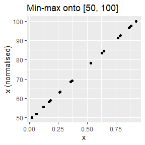

```r
# example data
set.seed(69)
x <- runif(20)

library(ggplot2)
# generic plot function to use in the other examples
nplot <- function(x, y, plot_title = NULL){
  ggplot(data = NULL, aes(x = x, y = y)) +
    geom_point() +
    xlab("x") +
    ylab("x (normalised)") +
    ggtitle(plot_title)
}

# rescale onto [50, 100] interval
xdash <- n_minmax(x, l_u = c(50, 100))
nplot(x, xdash, "Min-max onto [50, 100]")
```

The transformation is analogous for negative-direction indicators.

### Z-score

The z-score function `n_zscore()` calculates z-scores which rescales $x$ to have a specified mean $\mu$ and standard deviation $\sigma$ (by default 0 and 1 respectively).

$$x' = \frac{x - \text{mean}(x)}{\text{std}(x)} \times \sigma + \mu$$

For example, specifying to have mean 10 and standard deviation 2:

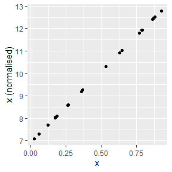

```r
nplot(x, n_zscore(x, c(10, 2)))
```

### Scaling

The `n_scaled()` function is a generic linear scaling function with parameters $u$ and $l$ of the form:

$$x' = \frac{x-l}{u-l} \times 100$$

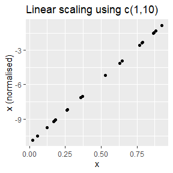

```r
nplot(x, n_scaled(x, c(1,10)), "Linear scaling using c(1,10)")
```

### Distance to maximum

Normalises as a measure of the distance to the maximum value, where the maximum value is the highest-scoring value. The formula used is:

$$x' = 1 - \frac{x_{max} - x}{x_{max} - x_{min}}$$

This means that the closer a value is to the maximum, the higher its score will be. Scores will be in the range of 0 to 1.

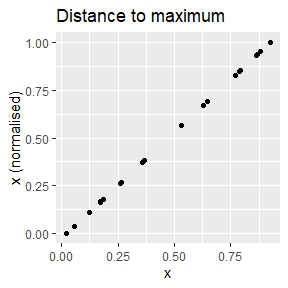

```r
nplot(x, n_dist2max(x), "Distance to maximum")
```

### Fraction of maximum

The `n_fracmax()` function simply measures each point as a fraction of the maximum observed value in $x$.

$$x' = \frac{x}{x_{max}}$$

This looks as follows (not very exciting since $x$ is already on a $[0,1]$ scale):

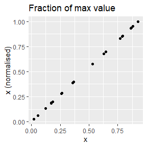

```r
nplot(x, n_fracmax(x), "Fraction of max value")
```

## Rank methods

### Ranks

The most simple rank-based approach is to directly take the rank. This can be done using base R functions, or using the wrapper `n_rank()`, set for the purposes of normalisation so that higher scores will give higher rank values, and sets ties to the minimum value by default.

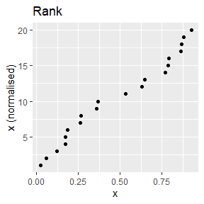

```r
nplot(x, n_rank(x), "Rank")
```

### Borda

The `n_borda()` function calculates [Borda scores](https://en.wikipedia.org/wiki/Borda_count) as:

$$x' = \text{rank}(x) - 1$$

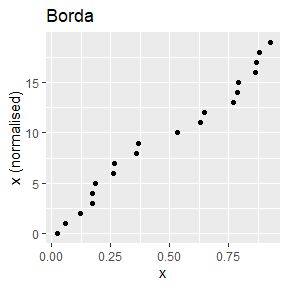

```r
# normalise
xdash <- n_borda(x)
nplot(x, xdash, "Borda")
```

Caution may be necessary with Borda scores when comparing indicators with different numbers of missing values. See the following discussion in Percentile ranks.

### Percentile ranks

The percentile rank function `n_prank()` converts an indicator to [percentile ranks](https://en.wikipedia.org/wiki/Percentile_rank), which are *the percentage of scores in its frequency distribution that are less than that score*.

Percentile ranks act like ranks, but have the added nice property that they don’t depend on the number of observations. For example: if we convert an indicator with 100 observed values using Borda scores we will end up with scores in the range $[0, 99]$. Another indicator in the same data set with only 75 observed values (the rest are `NA`) would on the other hand get scores in the range $[0,74]$! On the other hand, percentile ranks always scale onto the $[0, 1]$ interval.

An indicator normalised by percentile ranks looks as follows:

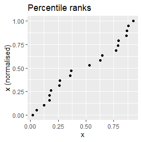

```r
nplot(x, n_prank(x), "Percentile ranks")
```

## Targets and references

### Distance to a reference

The `n_dist2ref()` function gives a measure of the distance to a specific value $x_{\text{ref}}$ found in `x`. The formula is:

$$x' = 1 - \frac{x_{\text{ref}} - x}{x_{\text{ref}} - x_{min}}$$

In composite indicators, this is often used in the context of benchmarking scores against the scores of a specific country. The function therefore allows you to specify the index of the reference value as opposed to the value itself. Values exceeding x_ref`can be optionally capped at 1 if`cap_max = TRUE`.

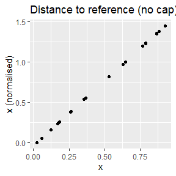

```r
xdash <- n_dist2ref(x, iref = 3, cap_max = FALSE)
nplot(x, xdash, "Distance to reference (no cap)")
```

With the cap, the result changes:

[figure not shown]

```r
xdash <- n_dist2ref(x, iref = 3, cap_max = TRUE)
nplot(x, xdash, "Distance to reference (no cap)")
```

*Important note: at the time of writing, `n_dist2ref()` does not allow for direction adjustment. This will hopefully be included in a future update.*

### Distance to target

The `n_dist2targ()` function gives the distance of each point in $x$ to a specified numerical target. This is different from the previous `n_dist2ref()` in that the target is specified as a fixed value, rather than the index of a point in $x$. Additionally, this function allows for adjustment by the direction of the indicator. For positive-direction indicators:

$$x' = \frac{x - x_{min}}{x_{targ} - x_{min}}$$

else for negative direction indicators:

$$x' = \frac{x_{max} - x}{x_{max} - x_{targ}}$$

The function also features the possibility to cap values that exceed the target, as `n_dist2ref()`. To see how this looks for a positive indicator (with cap):

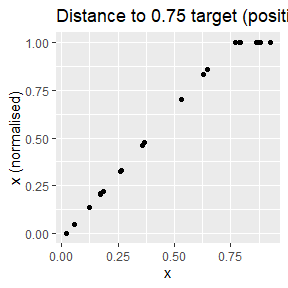

```r
xdash <- n_dist2targ(x, targ = 0.75, direction = 1, cap_max = TRUE)
nplot(x, xdash, "Distance to 0.75 target (positive direction: with cap)")
```

Similarly, with a negative direction and low target:

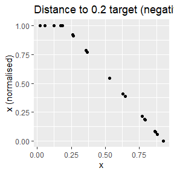

```r
xdash <- n_dist2targ(x, targ = 0.2, direction = -1, cap_max = TRUE)
nplot(x, xdash, "Distance to 0.2 target (negative direction: with cap)")
```

As explained in Goalposts, targets and iMeta specification, when applying this function to a coin you can specify the targets in the `iMeta` data frame.

### Goalposts

The goalposts function `n_goalposts()` normalises as the fraction of the distance of each value of $x$ from the lower “goalpost” to the upper one (these values are specified as function inputs). The direction of the function can be specified to measure positive or negative progress. Goalpost normalisation (sometimes known as “distance to frontier”) is often used when there is a logical lower and upper bound to the indicator.

For a positive indicator with goalposts $GP_{low}$ and $GP_{high}$:

$$x' = \frac{x - GP_{low}}{GP_{high} - GP_{low}}$$

and for a negative directionality indicator:

$$x' = \frac{x - GP_{high}}{GP_{low} - GP_{high}}$$

To see how this looks:

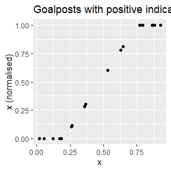

```r
xdash <- n_goalposts(x, gposts = c(0.2, 0.75, 1), direction = 1)
nplot(x, xdash, "Goalposts with positive indicator")
```

This is effectively a distance to target, but with upper and lower “targets”. The effect is analogous if the directionality is reversed:

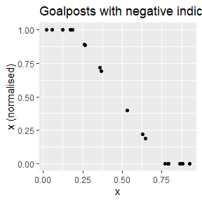

```r
xdash <- n_goalposts(x, gposts = c(0.2, 0.75, 1), direction = -1)
nplot(x, xdash, "Goalposts with negative indicator")
```

This normalisation function is also supported such that goalposts can be directly entered in `iMeta`. See Goalposts, targets and iMeta specification.